# Analytics 512: Take Home Final Exam

200 points in **nine** problems. This is the take-home portion of the exam. You may use your notes, your books, all material on the course website, and your computer or any computer in the departmental computer lab. You may also use official documentation for `R`, built-in or on https://cran.r-project.org/, but no other material on the Internet. Provide proper attribution for all such sources. You may not use any human help, except whatever help is provided by me.

Your solution should consist of two files: An .Rmd file that loads all data and all packages, makes all plots, and contains all comments and explanation, and an .html or .pdf file that is produced by the .Rmd file. Return your solutions in Canvas by Thursday, 5/10/18, 11:59PM

Problems A.1-A.6 use the **Ozone** data that are available in the `mlbench` package. Problems B.1-B.3 use the `make.eight` function; see the code below.

# Part A: Ozone Data

**Preparation:** Load the **Ozone** data. Read the instructions. Delete the variables V2 and V3 (day of month and day of week). Change the names of the remaining variables to

month, dailymax, pressure, windlax, humlax, tsand, telmonte, invlax, pressgrad, invbasetemplax, vislax.

```r
rm(list = setdiff(ls(), lsf.str()))
library(mlbench)
data(Ozone)
Ozone <- subset(Ozone, select = -c(V2, V3))
names = c("month", "dailymax", "pressure", "windlax","humlax", "tsand","telmonte","invlax","pressgrad","invbasetemplax","vislax")
colnames(Ozone) <- names
```

The target (response) variable is **dailymax**, the daily ozone maximum.

### A.1 [10]

Make two more data set, one where all days with any missing observations are omitted and one where only those days with missing daily maximum are omitted. Are the days with missing data uniformly distributed over all twelve months? Explore this question with a chi-squared test. Explain your approach and summarize the conclusion.

First we use exploratory analysis to see if there is any trend of uniformity in the data. We can see that there is some shape to the bar plot, suggesting non-uniformity.

```r
ozone.omitall <- na.omit(Ozone)
ozone.omitmax <- Ozone[!is.na(Ozone$dailymax),]
ozone.na = Ozone[rowSums(is.na(Ozone)) > 0,]
days.na = ozone.na$month
days.na
```

```
##   [1] 1  1  1  1  1  1  1  1  1  1  1  1  1  1  2  2  2  2  2  2  2  2  2
##  [24] 2  2  2  3  3  3  3  3  3  3  3  3  3  4  4  4  4  4  4  4  4  4  5
##  [47] 5  5  5  5  5  5  5  5  5  5  5  5  5  5  5  5  5  5  5  5  6  6  6
##  [70] 6  6  6  6  6  6  6  6  6  6  7  7  7  7  7  7  7  7  7  7  7  7  7
##  [93] 7  7  7  7  7  8  8  8  8  8  8  8  8  8  8  8  8  8  8  8  8  9  9
## [116] 9  9  9  9  9  9  9  9  9  9  9  9  10 10 10 10 10 10 10 10 10 10 10
## [139] 10 10 11 11 11 11 11 11 11 11 11 11 11 11 11 12 12 12 12 12 12 12 12
## [162] 12 12
## Levels: 1 2 3 4 5 6 7 8 9 10 11 12
```

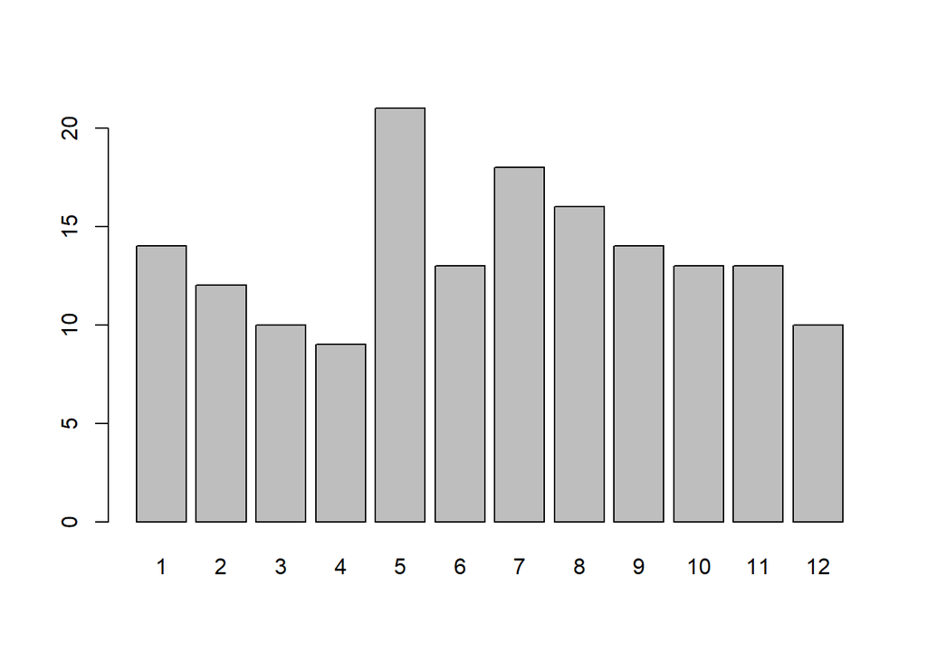

```r
barplot(table(days.na))
```

expected value of NAs in each month and the observed number of NAs in each month:

```r
exp = length(days.na)/12
exp
```

```
## [1] 13.58333
```

```r
obs = data.frame(table(days.na))$Freq
obs
```

```
##  [1] 14 12 10  9 21 13 18 16 14 13 13 10
```

Carry out the Chi-square test to see if the data is uniformly distributed:

$H_{0}$: The day of missing value in a month is uniformly distributed.

$H_{a}$: The day of missing value in a month is not uniformly distributed.

```r
observation <- c(obs)
res <- chisq.test(observation, p = rep(1/12,12))
res
```

```
##
##  Chi-squared test for given probabilities
##
## data:  observation
## X-squared = 9.638, df = 11, p-value = 0.5632
```

The p-value is really large so there is not enough evidence to suggest that the day with missing value in a month is not a uniform distribution.

Carry out the Chi-square test by hand:

```r
mytest = function(x){
  return(sum((x-exp)^2)/exp)}

# Try it out
X2.observed = mytest(obs)
print(X2.observed)
```

```
## [1] 9.638037
```

```r
null <-rmultinom(1,163,rep(1,12))
null <-as.vector(null)
names(null) <-c("1","2","3","4","5","6","7","8","9","10","11","12")
print(null)
```

```
##  1  2  3  4  5  6  7  8  9 10 11 12
## 11 14  8 10 13 16 15 11 15 17 18 15
```

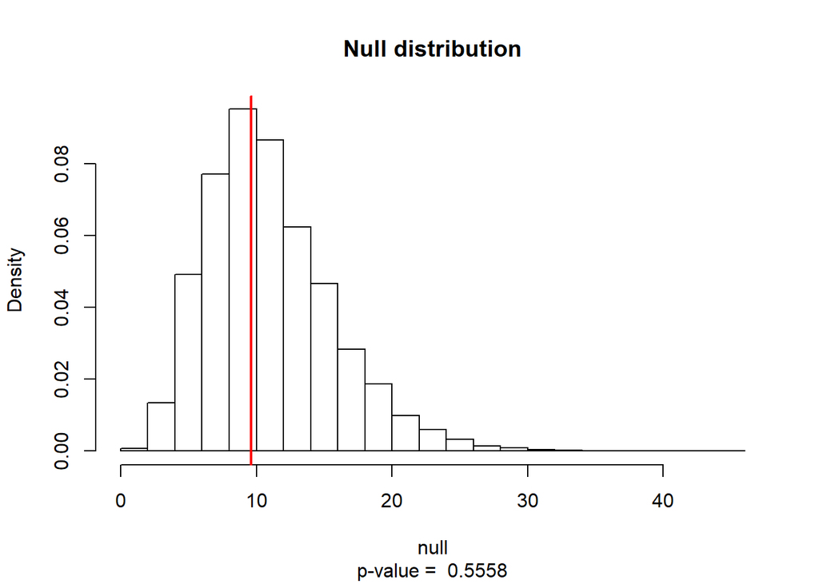

```r
N = 100000
null <- replicate(N,mytest(rmultinom(1,163,rep(1,12))))

hist(null, main = "Null distribution", sub = paste("p-value = ", round(mean(null > X2.observed),4)),prob=T)
abline(v = X2.observed, col = 2, lwd = 2)
```

We can see that the P-value is very large, so there is not enough evidence to reject the null hypoithesis to say that it is not a uniform distribution.

### A.2 [30]

Fit trees to predict **dailymax** from all variables except **month**, once from data with complete observations and once from data with complete daily maximum observations, but possibly missing data elsewhere. Find a short and convincing way to show that the two trees are the same.

```r
library(ISLR)
#set.seed(1)
#train <- sample(1:nrow(ozone.omitall), 4*nrow(ozone.omitall)/5)
#O.train <- ozone.omitall[train, ]
#O.test <- ozone.omitall[-train, ]
library(tree)
tree.complete <- tree(dailymax ~ . - month, data = ozone.omitall)
summary(tree.complete)
```

```
##
## Regression tree:
## tree(formula = dailymax ~ . - month, data = ozone.omitall)
## Variables actually used in tree construction:
## [1] "telmonte"       "tsand"          "invlax"         "pressgrad"
## [5] "invbasetemplax" "vislax"
## Number of terminal nodes:  11
## Residual mean deviance:  13.73 = 2636 / 192
## Distribution of residuals:
##    Min. 1st Qu.  Median    Mean 3rd Qu.    Max.
## -8.8670 -2.2990 -0.4808  0.0000  1.8890 12.7800
```

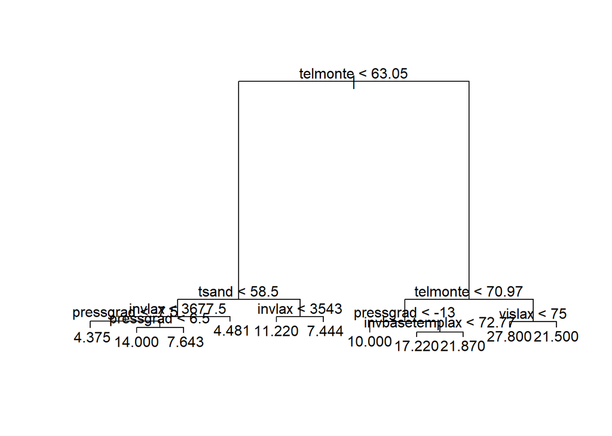

```r
plot(tree.complete)
text(tree.complete, pretty = 0)
```

```r
library(ISLR)
#set.seed(1)
#train <- sample(1:nrow(ozone.omitmax), 4*nrow(ozone.omitmax)/5)
#O.train.withna <- ozone.omitmax[train, ]
#O.test.withna <- ozone.omitmax[-train, ]

library(tree)
tree.withna <- tree(dailymax ~ . - month, data = ozone.omitmax)
summary(tree.withna)
```

```
##
## Regression tree:
## tree(formula = dailymax ~ . - month, data = ozone.omitmax)
## Variables actually used in tree construction:
## [1] "telmonte"       "tsand"          "invlax"         "pressgrad"
## [5] "invbasetemplax" "vislax"
## Number of terminal nodes:  11
## Residual mean deviance:  13.73 = 2636 / 192
## Distribution of residuals:
##    Min. 1st Qu.  Median    Mean 3rd Qu.    Max.
## -8.8670 -2.2990 -0.4808  0.0000  1.8890 12.7800
```

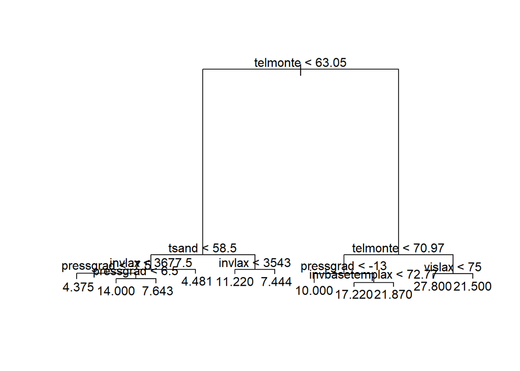

```r
plot(tree.withna)
text(tree.withna, pretty = 0)
```

Besides the fact that the Residual mean deviance and the distribution of residuals are the same for two models are exactly the same, from the tree plot we can also see that the shape of the tree and the division threshold of each branch are all the same for tow models. Two models fited using the complete data and partially missing data are completly the same.

### A.3 [20]

The daily ozone maximum can be predicted from the month alone, using the mean. Find a way to assess the rms error of this prediction using 10-fold cross validation.

Prepare the data for predicting the mean dailymax of the month using month:

```r
ozone.month = ozone.omitall[, 1:2]
month.agg = aggregate(ozone.month$dailymax, list(ozone.month$month), mean)
names(month.agg) <-c("month", "dailymax")
month.agg$month = as.numeric(month.agg$month)
```

We can see that there is a rough quadratic shape to the relationship between mean dailymax and month.

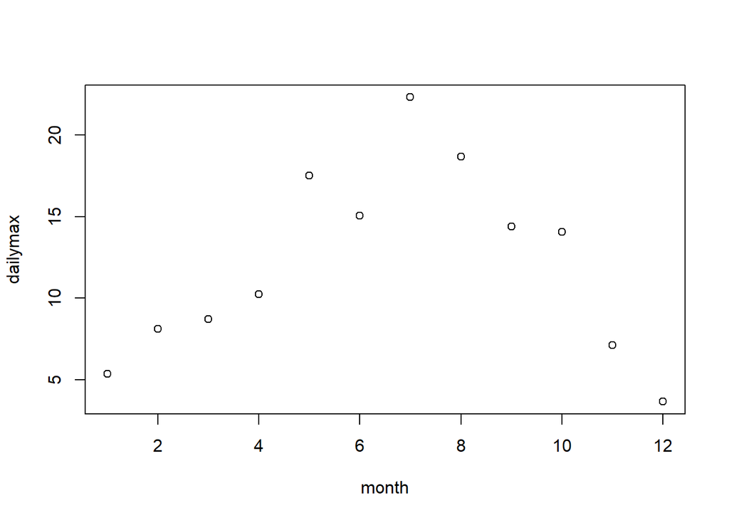

```r
plot(month.agg)
```

```r
library(boot)
cv.error=rep(0,5)
for (i in 1:5){
  glm.fit=glm(dailymax ~ poly(month, i), data=month.agg)
  cv.error[i]=cv.glm(month.agg, glm.fit, K=10)$delta[1]
}
cv.error
```

```
## [1] 46.56657 10.81924 10.18257 11.55134 14.54784
```

We can see that a cubic polynomial is the best fit for predicting dailymax using month because its model has the smallest CV error(10.18257).

```r
glm.cubic=glm(dailymax ~ poly(month, 3), data=month.agg)
summary(glm.cubic)
```

```
##
## Call:
## glm(formula = dailymax ~ poly(month, 3), data = month.agg)
##
## Deviance Residuals:
##     Min       1Q   Median       3Q      Max
## -2.4961  -1.9356   0.3332   0.9658   4.2098
##
## Coefficients:
##                 Estimate Std. Error t value Pr(>|t|)
## (Intercept)       12.098      0.708  17.088  1.4e-07 ***
## poly(month, 3)1    1.726      2.453   0.704 0.501608
## poly(month, 3)2  -17.111      2.453  -6.977 0.000115 ***
## poly(month, 3)3   -4.755      2.453  -1.939 0.088523 .
## ---
## Signif. codes:  0 '***' 0.001 '**' 0.01 '*' 0.05 '.' 0.1 ' ' 1
##
## (Dispersion parameter for gaussian family taken to be 6.014721)
##
##     Null deviance: 366.489  on 11  degrees of freedom
## Residual deviance:  48.118  on  8  degrees of freedom
## AIC: 60.719
##
## Number of Fisher Scoring iterations: 2
```

Delta in the result of 10-fold cross validation is the average mean-squared error that you obtain from doing 10-fold CV. RMS is the Root Mean Squared Error (RMSE), which is the square root of the obtained CV MSE.

```r
rms = sqrt(cv.glm(month.agg, glm.cubic, K=10)$delta[1])
rms
```

```
## [1] 3.191014
```

The RMS for 10-fold cross-validation for a cubic model is approximatly 3.19.

### A.4 [30]

Predict the daily ozone maximum from all variables except month, using a linear model and only observations with complete measurements. Identify all significant variables.

Assess the rms error using 10 fold CV.

```r
library(boot)
linear.model=glm(dailymax ~ .- month, data = ozone.omitall)
summary(linear.model)
```

```
##
## Call:
## glm(formula = dailymax ~ . - month, data = ozone.omitall)
##
## Deviance Residuals:
##      Min        1Q    Median        3Q       Max
## -11.2055   -2.7232   -0.2741    3.0891   13.3442
##
## Coefficients:
##                  Estimate Std. Error t value Pr(>|t|)
## (Intercept)    59.9517553 38.3286940   1.564 0.119421
## pressure       -0.0139111  0.0072511  -1.918 0.056527 .
## windlax         0.0276862  0.1741433   0.159 0.873847
## humlax          0.0808740  0.0237694   3.402 0.000812 ***
## tsand           0.1503404  0.0692994   2.169 0.031272 *
## telmonte        0.5253439  0.1247136   4.212 3.87e-05 ***
## invlax         -0.0010052  0.0003944  -2.549 0.011586 *
## pressgrad       0.0049796  0.0147772   0.337 0.736501
## invbasetemplax -0.1543882  0.1192917  -1.294 0.197140
## vislax         -0.0033951  0.0048963  -0.693 0.488883
## ---
## Signif. codes:  0 '***' 0.001 '**' 0.01 '*' 0.05 '.' 0.1 ' ' 1
##
## (Dispersion parameter for gaussian family taken to be 20.08543)
##
##     Null deviance: 13549.5  on 202  degrees of freedom
## Residual deviance:  3876.5  on 193  degrees of freedom
## AIC: 1196.8
##
## Number of Fisher Scoring iterations: 2
```

As we can see from the result above, the sinificant variables are: humlax, tsand, telmonte, invlax.

```r
sqrt(cv.glm(ozone.omitall, linear.model, K=10)$delta[1])
```

```
## [1] 4.577025
```

### A.5 [20]

Use the LASSO for the linear model from the previous problem, once with standardization and once without. For each case, plot the coefficient trajectories as a function of the regularization parameter $\lambda$ and determine the last five variables that leave the model as $\lambda$ increases.

In the case of standarization:

```r
x=model.matrix(dailymax ~ .-month, ozone.omitall)[,-1]
y=ozone.omitall$dailymax
x.sd = x
for (j in 1:9){x.sd[,j] <- x.sd[,j]/sqrt(sum(x.sd[,j]^2))}

library(glmnet)
```

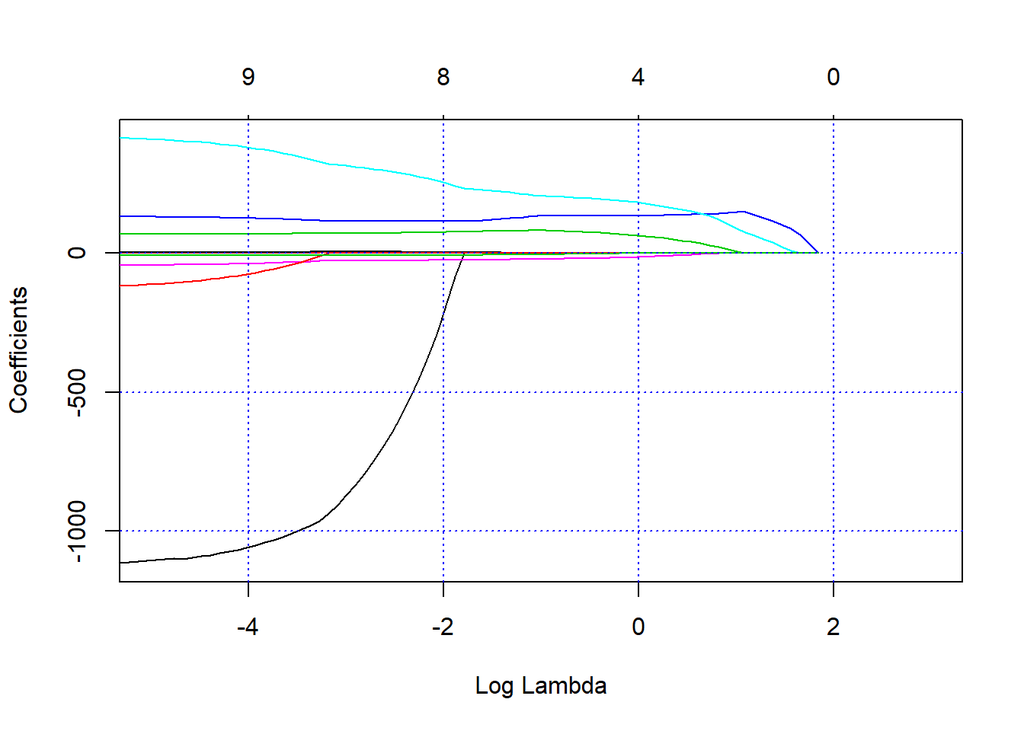

```r
set.seed(0507)
lasso.mod = glmnet(x.sd,y,alpha = 1)
plot(lasso.mod, xvar = "lambda", xlim=range(-5:3.5))
grid(col = 4)
```

```r
#cv.lasso =cv.glmnet(x,y,alpha =1)
#plot(cv.lasso)
#bestlam =cv.lasso$lambda.min
#bestlam
#predict(lasso.mod, s=bestlam, type ="coefficients")
lasso.mod$beta
```

```
## 9 x 81 sparse Matrix of class "dgCMatrix"
```

```
##    [[ suppressing 81 column names 's0', 's1', 's2' ... ]]
```

```
##
## pressure       .  .        .        .          .         .         .
## windlax        .  .        .        .          .         .         .
## humlax         .  .        .        .          .         .         .
## tsand          . 35.36178 67.58212 89.738773 103.70855 116.50214 128.05008
## telmonte       .  .        .        8.900546  24.47039  38.59105  51.56831
## invlax         .  .        .        .          .         .         .
## pressgrad      .  .        .        .          .         .         .
## invbasetemplax .  .        .        .          .         .         .
## vislax         .  .        .        .          .         .         .
##
## pressure         .         .         .          .         .
## windlax          .         .         .          .         .
## humlax           .         .         6.035839  14.71788  22.64136
## tsand          138.67987 148.25858 149.413752 146.52580 143.78260
## telmonte        63.28306  74.06575  89.460009 106.37011 121.88724
## invlax           .         .         .          .         .
## pressgrad        .         .         .          .         .
## invbasetemplax   .         .         .          .         .
## vislax           .         .         .          .         .
##
## pressure         .           .         .          .         .
## windlax          .           .         .          .         .
## humlax          29.8520498  35.75098  41.185404  46.13019  50.647990
## tsand          140.9209212 140.53464 139.648401 138.89928 138.112035
## telmonte       136.0456026 143.57445 150.989595 157.68681 163.895175
## invlax          -0.2177439  -2.42339  -4.419196  -6.23897  -7.894803
## pressgrad        .           .         .          .         .
## invbasetemplax   .           .         .          .         .
## vislax           .           .         .          .         .
##
## pressure         .          .         .         .         .
## windlax          .          .         .         .         .
## humlax          54.752787  58.50440  61.91129  65.02667  67.85407
## tsand          137.493939 136.83308 136.32830 135.77348 135.36332
## telmonte       169.451433 174.61310 179.21752 183.50908 187.32272
## invlax          -9.405694 -10.78024 -12.03479 -13.17582 -14.21756
## pressgrad        .          .         .         .         .
## invbasetemplax   .          .         .         .         .
## vislax           .          .         .         .         .
```

[output cut: 125 more lines]

```
## telmonte         415.015236   416.240215   417.259196   418.288589
## invlax           -42.679721   -42.902990   -43.089956   -43.278202
## pressgrad          3.241098     3.205915     3.176232     3.145908
## invbasetemplax  -115.966495  -117.499193  -118.785155  -120.078175
## vislax            -7.148989    -7.148651    -7.149871    -7.149436
##
## pressure       -1119.729786
## windlax            2.167182
## humlax            70.647694
## tsand            132.881998
## telmonte         419.307318
## invlax           -43.463297
## pressgrad          3.116395
## invbasetemplax  -121.347370
## vislax            -7.147755
```

We can see from the above matrix, after standardizatoin, the last 5 variables that leaves the model when $lambda$ increase is humlax, tsand, telmonte, invlax and vislax.

In the case of **no** standarization:

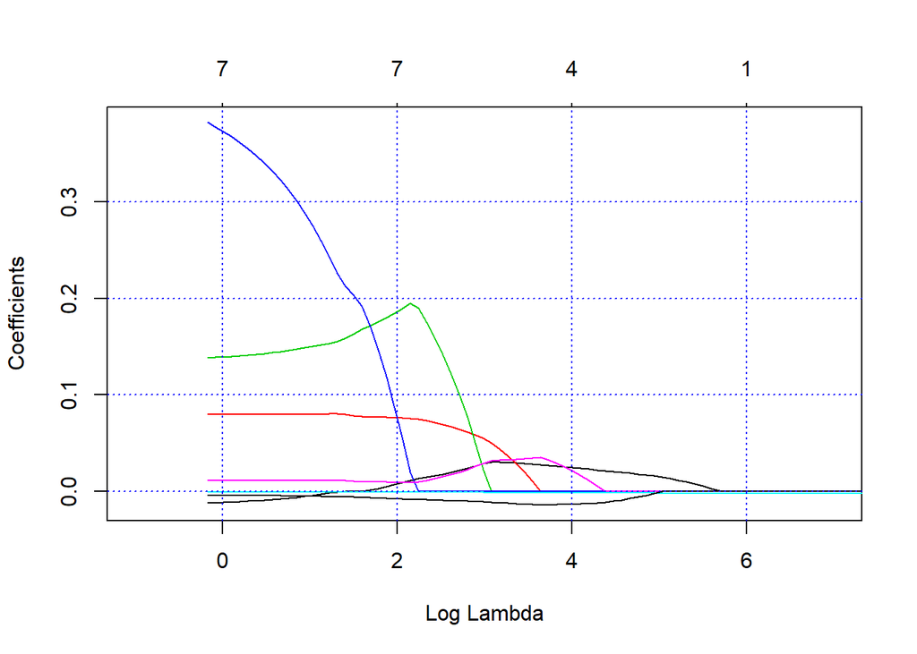

```r
set.seed(0507)
lasso.mod2 = glmnet(x,y,alpha = 1, standardize = F)
plot(lasso.mod2, xvar = "lambda", xlim=range(-1:7))
grid(col = 4)
```

```r
lasso.mod2$beta
```

```
## 9 x 100 sparse Matrix of class "dgCMatrix"
```

```
##    [[ suppressing 100 column names 's0', 's1', 's2' ... ]]
```

```
##
## pressure       .  .             .             .             .
## windlax        .  .             .             .             .
## humlax         .  .             .             .             .
## tsand          .  .             .             .             .
## telmonte       .  .             .             .             .
## invlax         . -0.0002166935 -0.0004141365 -0.0005940392 -0.0007579598
## pressgrad      .  .             .             .             .
## invbasetemplax .  .             .             .             .
## vislax         .  .             .             .             .
##
## pressure        .             .            .            .
## windlax         .             .            .            .
## humlax          .             .            .            .
## tsand           .             .            .            .
## telmonte        .             .            .            .
## invlax         -0.0009073182 -0.001043408 -0.001167408 -0.001280392
## pressgrad       .             .            .            .
## invbasetemplax  .             .            .            .
## vislax          .             .            .            .
##
## pressure        .            .           .            .
## windlax         .            .           .            .
## humlax          .            .           .            .
## tsand           .            .           .            .
## telmonte        .            .           .            .
## invlax         -0.001383339 -0.00147714 -0.001562609 -0.001640484
## pressgrad       .            .           .            .
## invbasetemplax  .            .           .            .
## vislax          .            .           .            .
##
## pressure        .            .            .            .
## windlax         .            .            .            .
## humlax          .            .            .            .
## tsand           .            .            .            .
## telmonte        .            .            .            .
## invlax         -0.001711442 -0.001776095 -0.001835005 -0.001888682
## pressgrad       .            .            .            .
## invbasetemplax  .            .            .            .
## vislax          .            .            .            .
```

[output cut: 195 more lines]

```
## telmonte        0.3484070108  0.355466052  0.3618903204  0.3677359184
## invlax         -0.0006339981 -0.000628868 -0.0006241922 -0.0006199303
## pressgrad       0.0115044805  0.011505173  0.0115054649  0.0115054383
## invbasetemplax  .             .            .             .
## vislax         -0.0043603417 -0.004287554 -0.0042212450 -0.0041608363
##
## pressure       -0.0115620684 -0.0119249459 -0.0122601932
## windlax         .             .             .
## humlax          0.0797677496  0.0797603798  0.0797452595
## tsand           0.1393403847  0.1388263447  0.1382423940
## telmonte        0.3730532261  0.3778878732  0.3824706585
## invlax         -0.0006160454 -0.0006125037 -0.0006093047
## pressgrad       0.0115050803  0.0115043642  0.0115160366
## invbasetemplax  .             .             .
## vislax         -0.0041058059 -0.0040556801 -0.0040092971
```

We can see from the above matrix, after no standardizatoin, the last 5 variables that leaves the model when $lambda$ increase still: pressure, humlax, invlax, pressgrad, vislax. This is different from the case when we standarize the data first.

### A.6 [10]

In problems 2, 4, 5 you have identified several sets of variables that are probably useful for predicting **dailymax** (excluding month). Compare these sets. Which variables are in all or most models? Which variables appear only in a few models?

```r
summary(tree.complete)
```

```
##
## Regression tree:
## tree(formula = dailymax ~ . - month, data = ozone.omitall)
## Variables actually used in tree construction:
## [1] "telmonte"       "tsand"          "invlax"         "pressgrad"
## [5] "invbasetemplax" "vislax"
## Number of terminal nodes:  11
## Residual mean deviance:  13.73 = 2636 / 192
## Distribution of residuals:
##    Min. 1st Qu.  Median    Mean 3rd Qu.    Max.
## -8.8670 -2.2990 -0.4808  0.0000  1.8890 12.7800
```

```r
summary(linear.model)
```

```
##
## Call:
## glm(formula = dailymax ~ . - month, data = ozone.omitall)
##
## Deviance Residuals:
##      Min        1Q    Median        3Q       Max
## -11.2055   -2.7232   -0.2741    3.0891   13.3442
##
## Coefficients:
##                  Estimate Std. Error t value Pr(>|t|)
## (Intercept)    59.9517553 38.3286940   1.564 0.119421
## pressure       -0.0139111  0.0072511  -1.918 0.056527 .
## windlax         0.0276862  0.1741433   0.159 0.873847
## humlax          0.0808740  0.0237694   3.402 0.000812 ***
## tsand           0.1503404  0.0692994   2.169 0.031272 *
## telmonte        0.5253439  0.1247136   4.212 3.87e-05 ***
## invlax         -0.0010052  0.0003944  -2.549 0.011586 *
## pressgrad       0.0049796  0.0147772   0.337 0.736501
## invbasetemplax -0.1543882  0.1192917  -1.294 0.197140
## vislax         -0.0033951  0.0048963  -0.693 0.488883
## ---
## Signif. codes:  0 '***' 0.001 '**' 0.01 '*' 0.05 '.' 0.1 ' ' 1
##
## (Dispersion parameter for gaussian family taken to be 20.08543)
##
##     Null deviance: 13549.5  on 202  degrees of freedom
## Residual deviance:  3876.5  on 193  degrees of freedom
## AIC: 1196.8
##
## Number of Fisher Scoring iterations: 2
```

In A.2, the variables included in our tree model are: “telmonte”, “tsand”, “invlax”, “pressgrad”, “invbasetemplax”, “vislax”. In A.4, the variables included in our linear model are: “telmonte”, “tsand”, “invlax”, “humlax”. In A.5, the last 5 variables leaving our lasso model are: “telmonte”, “tsand”, “invlax”, “humlax”, “vislax”.

Across these three models, “telmonte”, “tsand”, and “invlax” are in all of them; “pressgrad”, “invbasetemplax”, “vislax”, and “humlax” are only included in a some of them three models.

# Part B: Artificial Data

**Preparation:** Use the following function code. Familiarize yourself with its output.

Use the function to make two datasets with 2000 observations each, one for training, one for testing. Set the random seed to 2019 before doing this.

### B.1 [30]

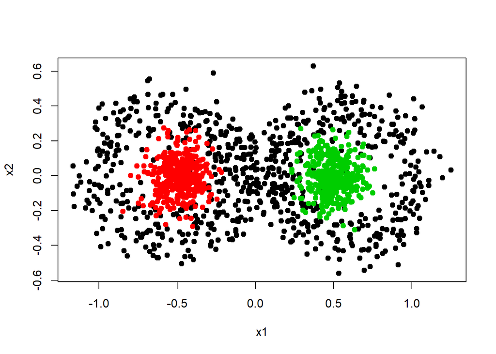

```r
make.eight = function(N, spread = .1, makeplot = T){
  # Make N points:  N/2 points in horizontal figure 8
  # N/4 points each inside the holes of the figure 8
  # spread = noise parameter
  # return data frame with coordinates x, y for each point
  # Classification variables in the data frame:
  #    charlabel =   eight   or   left   or  right
  #    label = 0 (for points on the figure 8) or = 1 (for points inside the holes)
  # plot with marked points if makeplot = T

  # Try these examples:
  # mydf <- make.eight(200)
  # mydf <- make.eight(100,spread = .05)
  # mydf <- make.eight(300,spread = .1, makeplot = F)
  #set.seed(2019)
  circ0 = runif(N/2)*2*pi
  circ = matrix(c(cos(circ0)/(1 + sin(circ0)^2),rep(-.5,N/4),rep(.5,N/4),
        cos(circ0)*sin(circ0)/(1 + sin(circ0)^2),rep(0,N/2)),ncol = 2)
  x = circ + spread*matrix(rnorm(2*N),N,2)
  y=rep(c(0,1),c(N/2,N/2))
  if(makeplot){plot(x,col = c(rep(1,N/2),rep(2,N/4),rep(3,N/4)),pch=19,
        xlab = "x1", ylab = "x2")}
  A = data.frame(x = x[,1], y = x[,2], label = as.factor(y),
        charlabel = c(rep("eight",N/2),rep("left",N/4), rep("right",N/4)))
  return(A)
}


df = make.eight(1500,spread = .1, makeplot = T)
```

1. Build a tree from the training set to predict the label from x and y. Do not use the variable **charlabel**. Plot the tree, evaluate it on the training set and on the test set, and make confusion matrices.

```r
library(ISLR)
set.seed(1)
df.label = df[-4]
train.sample <- sample(1:1500, 1100)
train.label <- df.label[train.sample, ]
test.label <- df.label[-train.sample, ]

library(tree)
tree.df <- tree(label ~ ., data = train.label)
summary(tree.df)
```

```
##
## Classification tree:
## tree(formula = label ~ ., data = train.label)
## Number of terminal nodes:  13
## Residual mean deviance:  0.3933 = 427.5 / 1087
## Misclassification error rate: 0.06909 = 76 / 1100
```

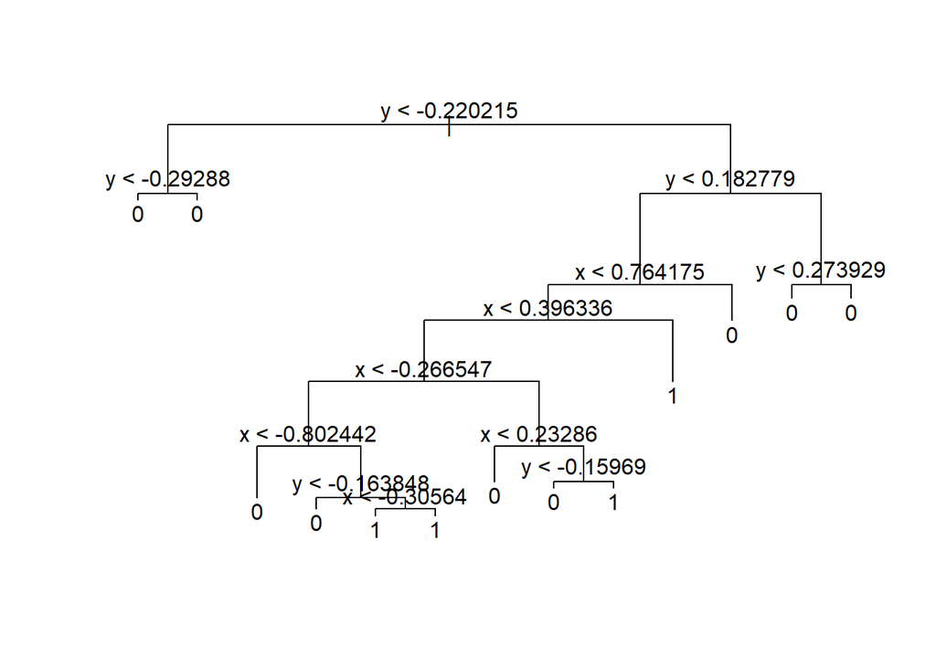

```r
plot(tree.df)
text(tree.df, pretty = 0)
```

```r
df.pred <- predict(tree.df, test.label, type = "class")
table(df.pred, test.label$label)
```

```
##
## df.pred   0   1
##       0 177  17
##       1  11 195
```

```r
mean(df.pred != test.label$label)
```

```
## [1] 0.07
```

For unpruned tree:

2. This tree can obviously be pruned. Explain how one can tell and explain how many terminal nodes should be used for the pruned tree. Verify that the pruned tree gives the same predictions for the training and test data. Do not use CV to decide on the tree size.

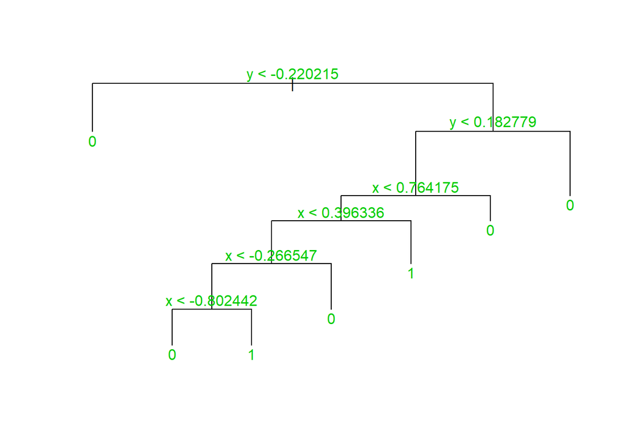

```r
prune.tree = prune.misclass(tree.df, best = 7)
plot(prune.tree)
text(prune.tree, col = 3)
```

```r
summary(prune.tree)
```

```
##
## Classification tree:
## snip.tree(tree = tree.df, nodes = c(2L, 7L, 97L, 49L))
## Number of terminal nodes:  7
## Residual mean deviance:  0.5676 = 620.4 / 1093
## Misclassification error rate: 0.09182 = 101 / 1100
```

```r
df.pred.prune <- predict(prune.tree, test.label, type = "class")
table(df.pred.prune, test.label$label)
```

```
##
## df.pred.prune   0   1
##             0 180  27
##             1   8 185
```

```r
mean(df.pred.prune != test.label$label)
```

```
## [1] 0.0875
```

For pruned tree:

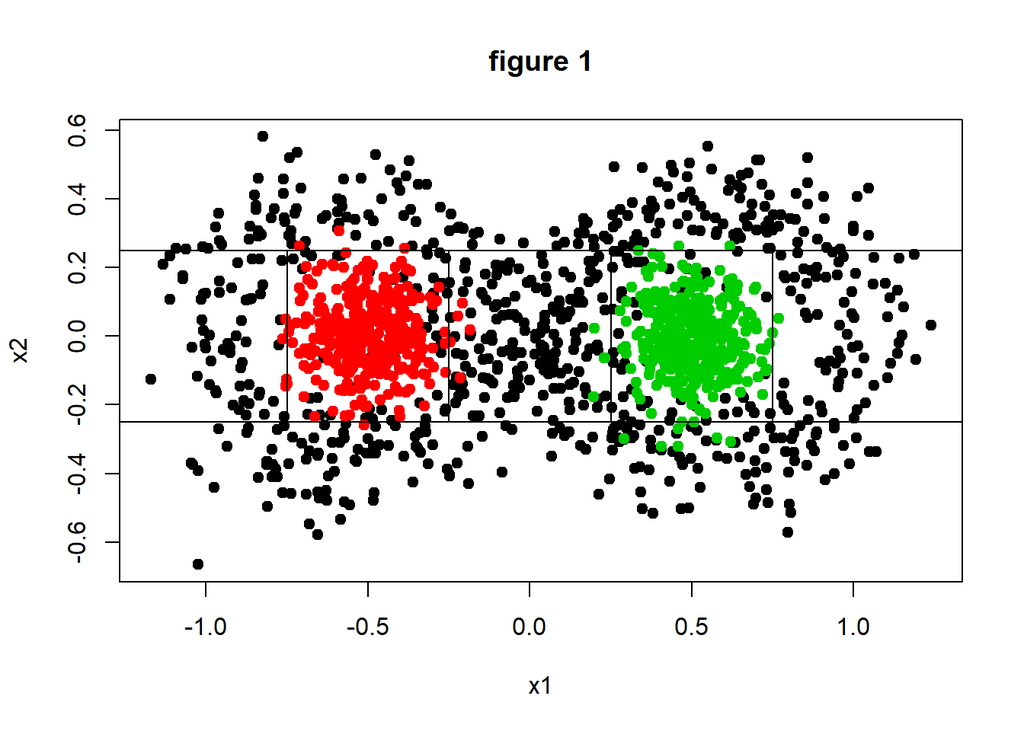

```r
df = make.eight(1500,spread = .1, makeplot = T)
abline(0.25,0)
abline(-0.25,0)
segments(-0.75,-0.25,-0.75,0.25)
segments(-0.25,-0.25,-0.25,0.25)
segments(0.75,-0.25,0.75,0.25)
segments(0.25,-0.25,0.25,0.25)
title("figure 1")
```

3. Explain why pruning any tree for data such as these to fewer than six nodes will most likely result in substantially worse performance. Demonstrate this with an example.

```r
bad.prune <- prune.misclass(tree.df, best = 3)
summary(bad.prune)
```

```
##
## Classification tree:
## snip.tree(tree = tree.df, nodes = c(2L, 7L, 6L))
## Variables actually used in tree construction:
## [1] "y"
## Number of terminal nodes:  3
## Residual mean deviance:  1.037 = 1138 / 1097
## Misclassification error rate: 0.2473 = 272 / 1100
```

```r
#text(bad.prune, pretty = 0)
bad.prune.pred <- predict(bad.prune, test.label, type = "class")
table(bad.prune.pred, test.label$label)
```

```
##
## bad.prune.pred   0   1
##              0 113  10
##              1  75 202
```

```r
mean(bad.prune.pred != test.label$label)
```

```
## [1] 0.2125
```

### B.2 [30]

1. Fit a boosted tree model, with interaction depth < 3 (all other parameters are your choice, **but with the constraint that ntrees * shrinkage < 200**). Do not use the variable **charlabel**. Show that the model is incapable of fitting the training data very well (i.e. near perfectly with prediction error < 1%). Explain this phenomenon. Show that such a model still seems to be overfitting the training data. *You should make the label veriable numeric first.*

```r
library(gbm)
set.seed (1)
train.label$label = as.numeric(train.label$label) - 1

set.seed(3)
boost.label = gbm(label ~ ., data=train.label, distribution="gaussian", n.trees = 10000, interaction.depth = 2, shrinkage = 0.01)
boost.train.pred = predict(boost.label, newdata = train.label,type = 'response', n.trees = 1000)
boost.train.pred = ifelse(boost.train.pred > 0.5, 1, 0)
table.train = table(boost.train.pred,train.label$label)
table.train
```

```
##
## boost.train.pred   0   1
##                0 523  24
##                1  39 514
```

```r
mean(boost.train.pred != train.label$label)
```

```
## [1] 0.05727273
```

Error rate:

```r
boost.test.pred = predict(boost.label, newdata = test.label,type = 'response', n.trees = 100)
boost.test.pred = ifelse(boost.test.pred > 0.5, 1, 0)
table.label = table(boost.test.pred,test.label$label)
table.label
```

```
##
## boost.test.pred   0   1
##               0 133  26
##               1  55 186
```

```r
mean(boost.test.pred != test.label$label)
```

```
## [1] 0.2025
```

As we can see above, the training set miss classification rate is very high(5%) and the test set classification rate is even higher(20%). This is a sign of serious overfit.

2. Fit a boosted tree model with sufficiently large interaction depth. Do not use the variable **charlabel**. Demonstrate that the training data now can be fitted almost perfectly. Decide whether the model from part (a) or the model from part (b) should be used for new data.

```r
set.seed(1)
boost.label2 = gbm(label ~ ., data=train.label, distribution="gaussian", n.trees = 10000, interaction.depth = 49, shrinkage = 0.01)
boost.train.pred2 = predict(boost.label2, newdata = train.label,type = 'response', n.trees = 1000)
boost.train.pred2 = ifelse(boost.train.pred2 > 0.5, 1, 0)
table(boost.train.pred,train.label$label)
```

```
##
## boost.train.pred   0   1
##                0 523  24
##                1  39 514
```

```r
mean(boost.train.pred2 != train.label$label)
```

```
## [1] 0.01818182
```

```r
boost.test.pred2 = predict(boost.label2, newdata = test.label,type = 'response', n.trees = 10000, shrinkage = 0.01)
boost.test.pred2 = ifelse(boost.test.pred2 > 0.5, 1, 0)
table(boost.test.pred2,test.label$label)
```

```
##
## boost.test.pred2   0   1
##                0 175  16
##                1  13 196
```

```r
mean(boost.test.pred2 != test.label$label)
```

```
## [1] 0.0725
```

As we can see from the above modeling result we can see that if we increase the interaction depth of the model, the result, both the training error and test error, are improved significantly. The model from part b should be used for new data because even though the second model shows some sign of overfitting the result is still far more superior than the first model.

### B.3 [20]

Make $N = 1000$ figure eight data points with spread = 0.05 and delete the variable **label**. You may want to keep **charlabel**. Set the random seed to 2019 before doing this.

You’ll apply clustering methods to this dataset. From looking at this data, one would expect (hope) that all the data in a point cloud inside one of the holes of the 8 will be in the same c luster. Find a way to determine if this is indeed the case. There are many ways to do this, including these possibilities: Make a scatterplot of the datapoints colored by cluster label, or plot the cluster labels against the row index, or make a two-way table of **charlabel** and “membership” in each cluster, and so on. Choose an approach and explain why you expect it to work.

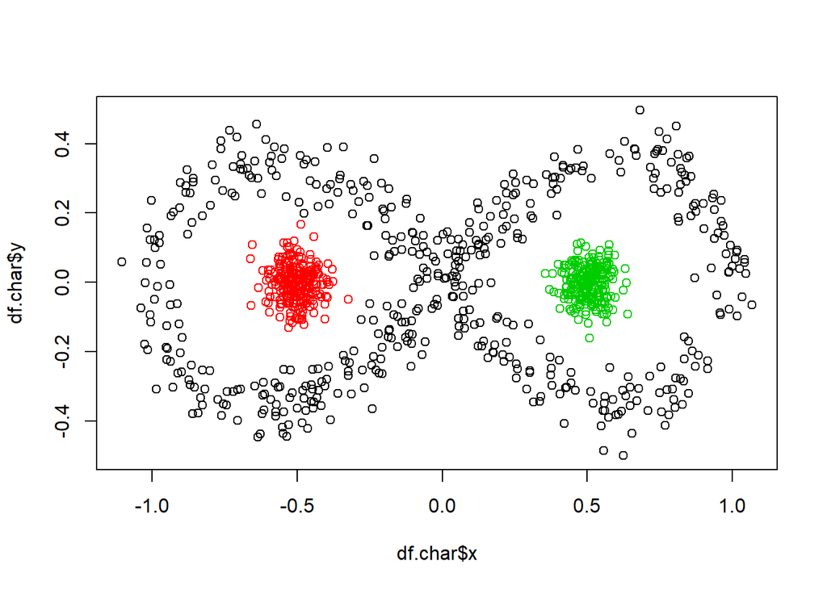

```r
set.seed(2019)
df2 = make.eight(1000, spread = 0.05, makeplot = F)
df.char = df2[-3]
plot(df.char$x,df.char$y, col = df.char$charlabel)
```

From the plot above we can see that the 8 shape is its own cluster, and the cloud in each hole of the 8 are their own cluster.

1. Apply hierarchical clustering, with both single linkage and complete linkage. Cut the resulting trees at $k = 10$ and $k = 20$. In each case, evaluate the clustering results with the approach that you have selected to determine whether the two interior point clouds are captured by the clustering algorithm. When applicable, write down which cluster indices correspond to the left and right point clouds.

For single linkage:

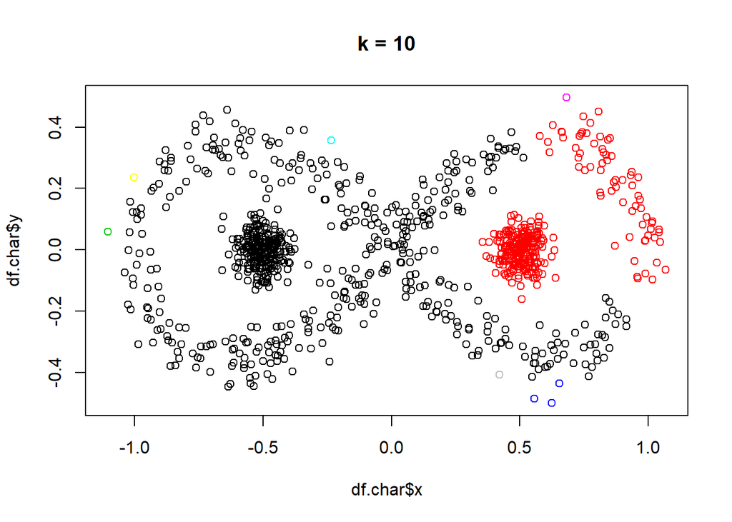

```r
h.single = hclust(dist(df.char[1:2]), method = 'single')
h.single.10 = cutree(h.single, 10)
h.single.20 = cutree(h.single, 20)
plot(df.char$x, df.char$y, col = h.single.10)
title("k = 10")
```

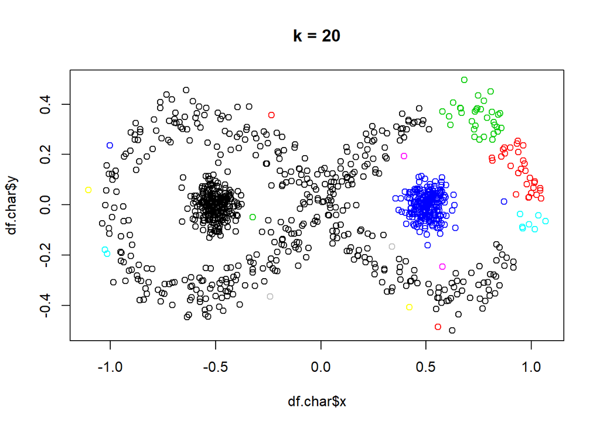

```r
plot(df.char$x, df.char$y, col = h.single.20)
title("k = 20")
```

Now we try complete linkage:

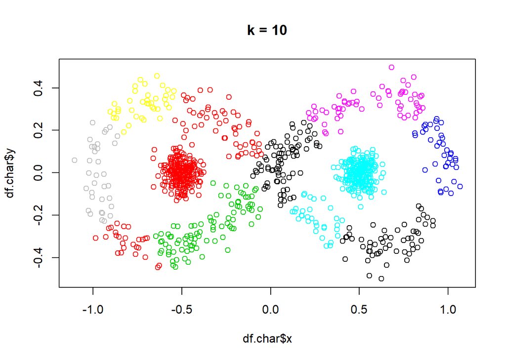

```r
h.complete = hclust(dist(df.char[1:2]), method = 'complete')
h.complete.10 = cutree(h.complete, 10)
h.complete.20 = cutree(h.complete, 20)
plot(df.char$x, df.char$y, col = h.complete.10)
title("k = 10")
```

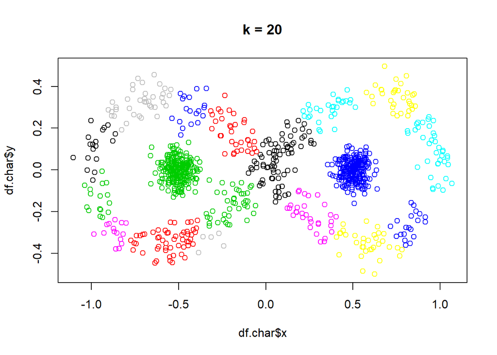

```r
plot(df.char$x, df.char$y, col = h.complete.20)
title("k = 20")
```

For both K = 10 and K = 20, we can see that the clustering result is unsuccessful. The tree fails to recognise the circular pattern. The interior points in this 4 trees are being assigned into clusters that also contains part of the 8 shape.

2. If single linkage clustering is applied, then one expects that cutting the tree to three clusters will identify the three clusters (figure eight, left cloud, right cloud) perfectly. But this will likely only happen if the data isn’t too noisy. We can control the data noise with the spread parameter of the `make.eight()` function. Determine for which spread value this happens, with evidence as in part (a). Set the random seed to 2019 before each run.

We use cross valisation to determine which spread is the threshold that hierarchical classification starts to correctly identify three clusters correctly. We make a sequence of different levels of spread and calculate the miss-clssification errors and find out which spread level does the first non-zero mass-classification error corresponds to. The tricky part is that, unlike logistic regression, in which case is supervised and the result classification can matches the original classification label so we can calculate the missclassification rate fairly easily, in the case of hierarchical classification, the classification result might not corresponds to the original classification lable, even though it identifies the clusters correctly. For instance, if the original data is lables as (1,1,1,2,2,3), the hierarchical classificsation result might generate an classification result as (2,2,2,1,1,3), which is 100% correctness for the three clusters but hard for us to calculate miss-classification error(100% missclassified labeling in this case!). In the case of hierarchical classification, the order of the labels is not the priority but rather it only has to correctly identify 3 clusters containing the right data points.

To overcome this difficulty, each time an hierarchical classification is run, we permute all possible orders of labels to calculate the miss-classification errors, the one with the lowest error within all possible permutations of the labels is the classification labeling result that corresponds to the “truth”. In the case of three lebels, we have 6 permutations of different order of the labels.

```r
require(combinat)
charlabel = c("eight","left","right")
perm = permn(charlabel)
perm
```

```
## [[1]]
## [1] "eight" "left"  "right"
##
## [[2]]
## [1] "eight" "right" "left"
##
## [[3]]
## [1] "right" "eight" "left"
##
## [[4]]
## [1] "right" "left"  "eight"
##
## [[5]]
## [1] "left"  "right" "eight"
##
## [[6]]
## [1] "left"  "eight" "right"
```

For instance, if the classification result is:

( **“left”**, **“right”**, **“right”**, **“eight”**, **“eight”**)

and the truth is:

(“eight”, “left” ,“left”,“right”,“right”).

We can see that the clustering result successfully recognize the clustering pattern for all data points(pattern of “one, two, two”) but fails to give the correct labeling order to calculate a 0% error rate, instead the error rate will be 100%.

To solve this issue, we calculate all 6 permutation of the labeling order and calculate a miss-classificastion error for each. After that, we choose the smallest one. The possible outcomes are:

(cluster 1(one), cluster 2(two), cluster 3(two) ):

(“eight”, “left”,“left”, “right”,“right”) (error rate 0%)

(“eight”, **“right”**, **“right”**, **“left”** , **“left”**) (error rate 80%)

( **“right”**, **“eight”**, **“eight”** , **“left”** , **“left”**) (error rate 100%)

( **“right”**, “left”, “left”, **“eight”**, **“eight”**) (error rate 60%)

( **“left”**, **“right”**, **“right”**, **“eight”**, **“eight”**) (error rate 100%)

( **“left”**, **“eight”**, **“eight”**, “right”,“right”). (error rate 60%)

As we can see, the first one out of all permutations mathces the labeling order of the truth so it will generate a 0% error rate while all other will have much higher error rate up to 100% because they got the order of the labeling wrong. In this example, we leave the error of the first permutation(0%) as the CV error of the current ith choice of spread. Do the same thing for all other choices of spread and we have an array of hierarchical cv error for each choice of spread. After that we choose the first non-zero error and find out which spread is that error corresponds to. The algorithm is carried out as the following:

```r
sequence = seq(0.01, 0.5, 0.005)
cv.errors =c()

for(i in sequence){
  set.seed(2019)
  df.temp = make.eight(1500, spread = i, makeplot = F)
  set.seed(2019)
  h.single.temp = hclust(dist(df.temp[1:2]), method = 'single')
  h.single.3.temp = cutree(h.single.temp, 3) #get the array of result with 3 clusters

  require(combinat)
  charlabel = c("eight","left","right")
  perm = permn(charlabel)
  perm.error = rep(NA, 6)
  for (j in 1:6){
    h.single.3.temp.new = h.single.3.temp
    h.single.3.temp.new = replace(h.single.3.temp.new,1 == h.single.3.temp,perm[[j]][1])
    h.single.3.temp.new = replace(h.single.3.temp.new,2 == h.single.3.temp,perm[[j]][2])
    h.single.3.temp.new = replace(h.single.3.temp.new,3 == h.single.3.temp,perm[[j]][3])
    perm.error[j] = mean(h.single.3.temp.new != as.character(df.temp$charlabel))
  }
  cv.errors = c(cv.errors,min(perm.error))

}
cv.errors
```

```
##  [1] 0.0000000000 0.0000000000 0.0000000000 0.0000000000 0.0000000000
##  [6] 0.0000000000 0.0000000000 0.0006666667 0.2520000000 0.5013333333
## [11] 0.5013333333 0.5013333333 0.5013333333 0.5013333333 0.5013333333
## [16] 0.5013333333 0.5013333333 0.5013333333 0.5013333333 0.5013333333
## [21] 0.5013333333 0.5013333333 0.5013333333 0.5013333333 0.5013333333
## [26] 0.5020000000 0.5020000000 0.5020000000 0.5013333333 0.5013333333
## [31] 0.5013333333 0.5013333333 0.5013333333 0.5013333333 0.5013333333
## [36] 0.5013333333 0.5013333333 0.5013333333 0.5013333333 0.5013333333
## [41] 0.5013333333 0.5013333333 0.5013333333 0.5013333333 0.5013333333
## [46] 0.5013333333 0.5013333333 0.5013333333 0.5013333333 0.5013333333
## [51] 0.5013333333 0.5013333333 0.5013333333 0.5013333333 0.5013333333
## [56] 0.5013333333 0.5020000000 0.5020000000 0.5020000000 0.5020000000
## [61] 0.5020000000 0.5020000000 0.5020000000 0.5020000000 0.5020000000
## [66] 0.5020000000 0.5020000000 0.5013333333 0.5013333333 0.5013333333
## [71] 0.5013333333 0.5013333333 0.5013333333 0.5013333333 0.5013333333
## [76] 0.5020000000 0.5020000000 0.5020000000 0.5020000000 0.5020000000
## [81] 0.5020000000 0.5020000000 0.5020000000 0.5020000000 0.5020000000
## [86] 0.5020000000 0.5020000000 0.5020000000 0.5020000000 0.5020000000
## [91] 0.5020000000 0.5020000000 0.5020000000 0.5020000000 0.5020000000
## [96] 0.5020000000 0.5020000000 0.5020000000 0.5020000000
```

From the array of CV error we can spot the first non-zero error rate is 0.0006666667. Next we find the corresponding indices and the spread:

```r
#Find the smallest non-zero CV error.
min.error = min(cv.errors[cv.errors > 0])
print(paste("The smallest non-zero CV error(threshold) is:",min.error))
```

```
## [1] "The smallest non-zero CV error(threshold) is: 0.000666666666666667"
```

```r
#Find which index in cross validation that we find the smallest non-zero CV error.
index.of.min = which(cv.errors %in% min.error)
print(paste("The index in cross validation that we find the smallest non-zero CV error is:",index.of.min))
```

```
## [1] "The index in cross validation that we find the smallest non-zero CV error is: 8"
```

```r
#Find out the corresponding spread value in the sequence of spread.
print(paste("The largest spread value that the hierarchical clustering method can still perform well is:", sequence[index.of.min]))
```

```
## [1] "The largest spread value that the hierarchical clustering method can still perform well is: 0.045"
```

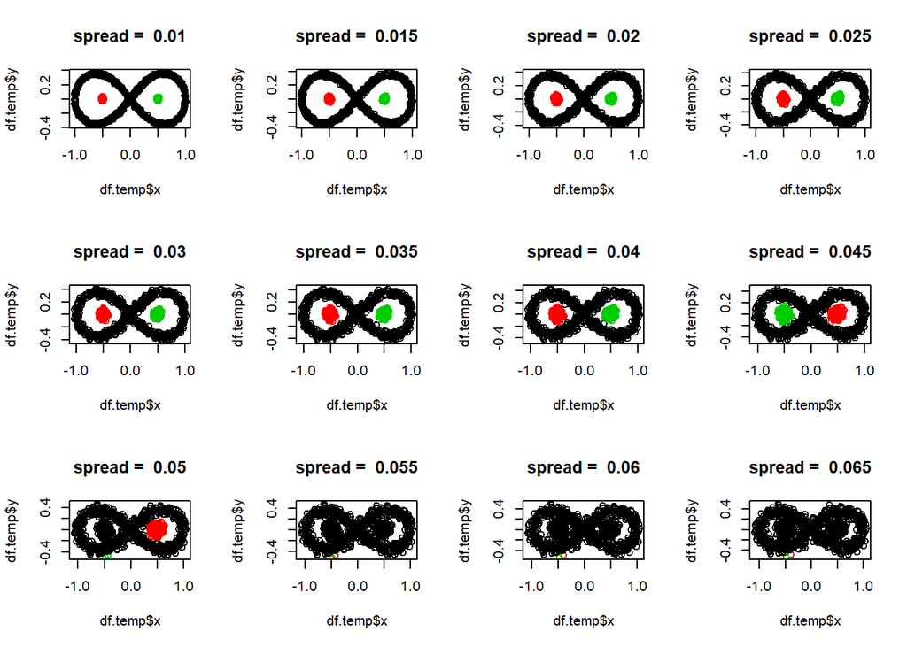

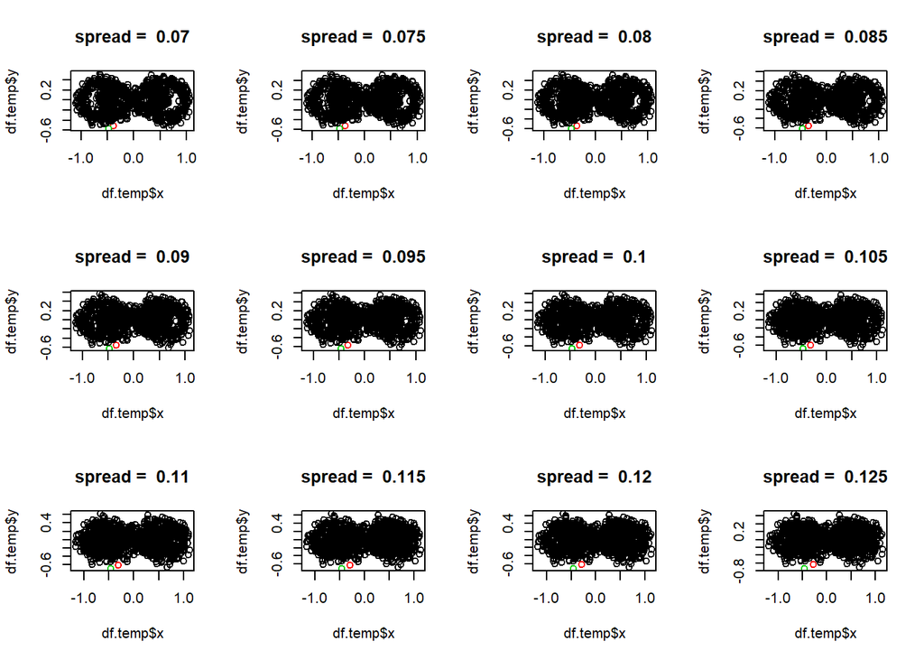

```r
par(mfrow=c(3,4))
sequence = seq(0.01, 0.5, 0.005)
cv.errors =c()

for(i in sequence){
  set.seed(2019)
  df.temp = make.eight(1500, spread = i, makeplot = F)
  set.seed(2019)
  h.single.temp = hclust(dist(df.temp[1:2]), method = 'single')
  h.single.3.temp = cutree(h.single.temp, 3) #get the array of result with 3 clusters

  require(combinat)
  charlabel = c("eight","left","right")
  perm = permn(charlabel)
  perm.error = rep(NA, 6)
  for (j in 1:6){
    h.single.3.temp.new = h.single.3.temp
    h.single.3.temp.new = replace(h.single.3.temp.new,1 == h.single.3.temp,perm[[j]][1])
    h.single.3.temp.new = replace(h.single.3.temp.new,2 == h.single.3.temp,perm[[j]][2])
    h.single.3.temp.new = replace(h.single.3.temp.new,3 == h.single.3.temp,perm[[j]][3])
    perm.error[j] = mean(h.single.3.temp.new != as.character(df.temp$charlabel))
  }
  cv.errors = c(cv.errors,min(perm.error))


  ###############algorithm is the same up to this point###############

  #Plot the classificaiton result of the data with spread choise smaller than 0.125:
  if(i<=0.125){
    plot(df.temp$x, df.temp$y, col = h.single.3.temp)
    title(paste("spread = ",i))
  }

}
```

We can see that after spread = 0.045, the classification result start to turn really bad. Any result before spread = 0.045, the classification result can clearly recognise the 8 shape and the two point clouds in the holes of the 8.